# Análise Bibliométrica com R

Neste trabalho irei apresentar o workflow básico para a realização de uma análise bibliométrica utilizando o R e o pacote Bibliometrix a partir dos dados de publicações científicas obtidas na base de dados [Scopus](http://www.scopus.com).

A preparação do ambiente (instalação do R, RStudio e Bibliometrix) e a obtenção dos dados seguirão conforme a aula apresentada anteriormente. Mais informações sobre estas etapas podem ser obtidas [aqui](http://github.com/diegocavalca/data-science/bibliometric-analysis).

Este *markdown* foi desenvolvido baseado no [material oficial](http://htmlpreview.github.io/?https://github.com/massimoaria/bibliometrix/master/vignettes/bibliometrix-vignette.html) do Bibliometrix.

Inicialmente, se faz necessário carregar o pacote *Bibliometrix* no R, que irá ser responsável por todo o processamento e análise de indicadores de nosso trabalho.

```r
library(bibliometrix)
```

Com o ambiente preparado, iremos carregar os dados bibliométricos obtidos junto a base de dados Scopus.

```r
D <- readLines("scopus2.bib")
M <- convert2df(D, dbsource = "scopus", format = "bibtex")
```

```
Articles extracted   100
Articles extracted   200
Articles extracted   300
Articles extracted   400
Articles extracted   500
Articles extracted   600
Articles extracted   700
Articles extracted   800
Articles extracted   900
Articles extracted   1000
Articles extracted   1100
Articles extracted   1200
Articles extracted   1300
Articles extracted   1399
```

Para dar início a análise, é necessário executar o pré-processamento dos dados, preparando-os para posterior análise de indicadores. Além disso, algumas métricas interessantes podem ser extraídas.

```r
### (grafico) Processar resultados bibliometricos
results <- biblioAnalysis(M, sep = ";")
#plot(x = results, k = 10, pause = FALSE)
View(results$Authors)
```

Com os dados preparados, o Bibliometrix oferece um resumo completo do conjunto de publicações analisados, incluido:

- Resumo quantitativo
  - Artigos
  - Periódicos
  - Palavras-chave (Autorais e Indexadas)
  - Citações média por artigo
  - Período contemplado na pesquisa
- Evolução histórica (p/ ano)
- Autores mais produtivos
- Artigos mais citados
- Produção científica por país
- etc.

```r
### (console) Resumo dos resultados
S <- summary(object = results, k = 10, pause = FALSE)
```

```
Main Information about data

 Articles                              1399
 Sources (Journals, Books, etc.)       648
 Keywords Plus (ID)                    9452
 Author's Keywords (DE)                2101
 Period                                1958 - 2017
 Average citations per article         6.683

 Authors                               3690
 Author Appearances                    4455
 Authors of single authored articles   205
 Authors of multi authored articles    3485

 Articles per Author                   0.379
 Authors per Article                   2.64
 Co-Authors per Articles               3.18
 Collaboration Index                   3.29


Annual Scientific Production

 Year    Articles
    1958        1
    1968        4
    1969        5
    1970        1
    1971        4
    1972        3
    1973        6
    1974        4
    1975       15
    1976        8
    1977        8
    1978       13
    1979       39
    1980       17
    1981       12
    1982       14
    1983       15
```

[output cut: 133 more lines]

```


Most Relevant Keywords

        Author Keywords (DE)      Articles         Keywords-Plus (ID)     Articles
1  GIS                                  51 MAPPING                             243
2  ENGINEERING GEOLOGY                  34 GEOLOGICAL MAPPING                  188
3  LANDSLIDES                           24 GEOLOGICAL SURVEYS                  186
4  LANDSLIDE                            23 ENGINEERING GEOLOGY                 163
5  ENGINEERING GEOLOGICAL MAPPING       16 GEOLOGY                             154
6  GEOLOGY                              16 PETROLEUM ENGINEERING               113
7  REMOTE SENSING                       15 REMOTE SENSING                       75
8  GEOLOGICAL MAPPING                   14 GEOGRAPHIC INFORMATION SYSTEMS       72
9  KARST                                10 GIS                                  69
10 MAPPING                              10 PETROLEUM RESERVOIRS                 68
```

É possível também realizar uma análise cruzada entre os trabalhos do conjunto de dados onde, por exemplo, extrair quais os papers mais citados no conjunto de dados analisado.

```r
### (console/viewer) Referências (Papers) mais citadas, no conjunto de dados
CR_Papers = citations(M, field = "article", sep = ";")
CR_Papers <- as.data.frame(CR_Papers$Cited[1:10])
names(CR_Papers) <- c('Paper', 'Citations')
CR_Papers
```

| Paper | Citations |
| --- | --- |
| BIENIAWSKI, ZT, ENGINEERING ROCK MASS CLASSIFICATIONS, , WILEY, NEW YORK | 7 |
| HOEK, E, BROWN, ET, PRACTICAL ESTIMATES OF ROCK MASS STRENGTH INT J ROCK MECH MIN SCI, 34 (8), PP 1165-1186 | 7 |
| GUZZETTI, F, CARRARA, A, CARDINALI, M, REICHENBACH, P, LANDSLIDE HAZARD EVALUATION: A REVIEW OF CURRENT TECHNIQUES AND THEIR APPLICATION IN A MULTI-SCALE STUDY, CENTRAL ITALY GEOMORPHOLOGY, 31, PP 181… | 6 |
| SINGH, B, GOEL, RK, SOFTWARE FOR ENGINEERING CONTROL OF LANDSLIDE AND TUNNELLING HAZARDS, P 344 , A A BALKEMA (SWETS & ZEITLINGER), ROTTERDAM | 6 |
| BARTON, N, LIEN, R, LUNDE, J, ENGINEERING CLASSIFICATION OF ROCK MASSES FOR THE DESIGN OF TUNNEL SUPPORT ROCK MECHANICS, 6, PP 189-236 | 4 |
| BARTON, N, SOME NEW Q-VALUE CORRELATIONS TO ASSIST IN SITE CHARACTERISATION AND TUNNEL DESIGN INTERNATIONAL JOURNAL OF ROCK MECHANICS AND MINING SCIENCES, 39, PP 185-216 | 4 |
| BARTON, NR, LIEN, R, LUNDE, J, ENGINEERING CLASSIFICATION OF ROCK MASSES FOR THE DESIGN OF TUNNEL SUPPORT ROCK MECH, 6 (4), PP 189-239 | 4 |
| DEARMAN, WR, ENGINEERING GEOLOGICAL MAPPING, , BUTTERWORTH-HEINEMANN, OXFORD | 4 |
| DEARMAN, WR, FOOKES, PG, ENGINEERING GEOLOGICAL MAPPING FOR CIVIL ENGINEERING PRACTICE IN THE UNITED KINGDOM QUARTERLY JOURNAL OF ENGINEERING GEOLOGY, 7, PP 223-256 | 4 |
| GOEL, RK, JETHWA, JL, PAITHANKAR, AG, INDIAN EXPERIENCES WITH Q AND RMR SYSTEMS TUNNELLING AND UNDERGROUND SPACE TECHNOLOGY, 10 (1), PP 97-109 | 4 |

```r
#View(CR_Papers)
```

Ou ainda, é possível obter os autores mais referenciados dentro do conjunto de dados.

```r
CR_Authors = citations(M, field = "author", sep = ";")
CR_Authors <- as.data.frame(CR_Authors$Cited[1:10])
names(CR_Authors) <- c('Author', 'Citations')
CR_Authors
```

| Author | Citations |
| --- | --- |
| HOEK, E | 185 |
| BIENIAWSKI, ZT | 110 |
| FOOKES, PG | 98 |
| LEE, S | 87 |
| BARTON, N | 86 |
| PRADHAN, B | 82 |
| ROSE, EPF | 77 |
| HAEBERLI, W | 73 |
| GUZZETTI, F | 70 |
| IRIGARAY, C | 61 |

```r
#View(CR_Authors)
```

O Fator de Dominância é um importante indicador que mensura a produtividade de autores, calculando a razão entre o número de trabalhos em que o autor aparece como **Primeiro Autor** e o número total de trabalhos multi-autorais em que este aparece.

```r
# k = 10 registros
DF <- dominance(results, k = 10)
DF
```

|  | Dominance Factor | Multi Authored | First Authored | Rank by Articles | Rank by DF |
| --- | --- | --- | --- | --- | --- |
| WANG,Y | 0.6250000 | 8 | 5 | 8 | 1 |
| ZUQUETTE,L | 0.5000000 | 12 | 6 | 2 | 2 |
| YILMAZ,I | 0.5000000 | 8 | 4 | 9 | 3 |
| CULSHAW,M | 0.4545455 | 11 | 5 | 3 | 4 |
| HEARN,G | 0.4444444 | 9 | 4 | 6 | 5 |
| LI,Y | 0.3636364 | 11 | 4 | 4 | 6 |
| DEARMAN,W | 0.3333333 | 12 | 4 | 1 | 7 |
| PEJON,O | 0.3333333 | 9 | 3 | 7 | 8 |
| FOOKES,P | 0.2857143 | 7 | 2 | 10 | 9 |
| ZHANG,L | 0.1000000 | 10 | 1 | 5 | 10 |

O índice-H (H-index) é outra métrica importante para avaliar a relevância acadêmica de um autor. Ela leva em consideração o número de artigos com citações maiores ou iguais a esse número.

Por exemplo: um autor com índice-H = 15 indica que este autor possui 15 artigos com pelo menos 15 citações.

```r
authors = gsub(",", " ", names(results$Authors)[1:10])
indices <- Hindex(M, authors, sep = ";", years=10)
HI <- indices$H
HI
```

| Author | h_index | g_index | m_index | TC | NP |
| --- | --- | --- | --- | --- | --- |
| NA | 2 | 4 | 0.1818182 | 25 | 29 |
| DEARMAN W | 0 | 0 | 0.0000000 | 0 | 0 |
| ZUQUETTE L | 3 | 3 | 0.2727273 | 15 | 3 |
| CULSHAW M | 2 | 2 | 0.2000000 | 9 | 6 |
| LI Y | 4 | 5 | 0.4444444 | 28 | 10 |
| ZHANG L | 2 | 4 | 0.2222222 | 22 | 7 |
| HEARN G | 3 | 3 | 0.3333333 | 15 | 4 |
| PEJON O | 3 | 4 | 0.2727273 | 20 | 5 |
| WANG Y | 2 | 6 | 0.2857143 | 42 | 6 |
| YILMAZ I | 4 | 6 | 0.3636364 | 108 | 6 |

Dentro do conjunto de dados, os atributos dos papers estão conectados entre si através do próprio paper. Assim, por exemplo, Autor(es) estão interconectados com Periódicos, Palavras-chave com Data de publicação, etc. Essas conexões de diferentes atributos geram redes bipartidas que podem ser representadas como matrizes retangulares (Papers x ATRIBUTO_QUALQUER).

Logo, por exemplo, é possível gerar uma rede que apresenta o comportamento colaborativo entre países dentro da área de pesquisa em questão, ou seja, representa o modo como ocorre a transferência de conhecimento acadêmico.

```
IGRAPH UN-- 20 77 --
+ attr: name (v/c), id (v/c), size (v/n), color (v/c)
+ edges (vertex names):
 [1] CHINA         --ITALY          CHINA         --UNITED KINGDOM
 [3] CHINA         --UNITED STATES  CHINA         --UNITED STATES
 [5] CHINA         --UNITED STATES  CHINA         --UNITED STATES
 [7] CHINA         --CANADA         CHINA         --CANADA
 [9] ITALY         --GREECE         ITALY         --GERMANY
[11] ITALY         --FRANCE         ITALY         --FRANCE
[13] ITALY         --FRANCE         ITALY         --FRANCE
[15] ITALY         --SPAIN          UNITED KINGDOM--AUSTRALIA
+ ... omitted several edges
```

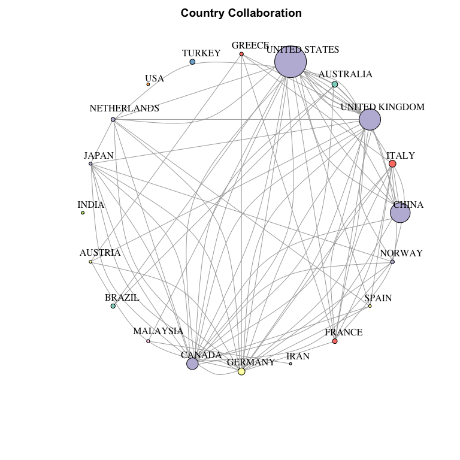

```r
M <- metaTagExtraction(M, Field = "AU_CO", sep = ";")
NetMatrix <- biblioNetwork(M, analysis = "collaboration", network = "countries", sep = ";")
networkPlot(NetMatrix, n = 20, Title = "Country Collaboration", type = "circle", size=TRUE, remove.multiple=FALSE)
```

Ou também, pode ser gerado uma rede de coocorrências de palavras-chave, permitindo analisar subáreas da área de conhecimento estudada.

```
IGRAPH UN-- 20 161 --
+ attr: name (v/c), id (v/c), size (v/n), color (v/c)
+ edges (vertex names):
 [1] ENGINEERING GEOLOGY--GEOLOGICAL SURVEYS
 [2] ENGINEERING GEOLOGY--GEOLOGY
 [3] ENGINEERING GEOLOGY--MAPPING
 [4] ENGINEERING GEOLOGY--GEOLOGICAL MAPPING
 [5] ENGINEERING GEOLOGY--SEISMOLOGY
 [6] ENGINEERING GEOLOGY--RISK ASSESSMENT
 [7] ENGINEERING GEOLOGY--GEOGRAPHIC INFORMATION SYSTEMS
 [8] ENGINEERING GEOLOGY--GROUNDWATER
+ ... omitted several edges
```

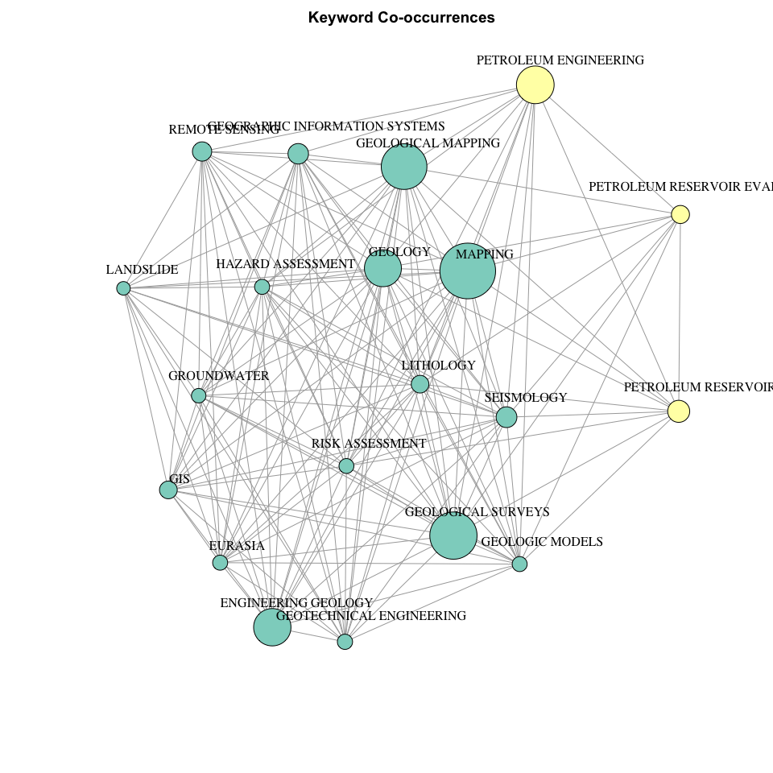

```r
# (grafico) Rede de co-ocorrencias de palavras-chave (20 keywords)
NetMatrix <- biblioNetwork(M, analysis = "co-occurrences", network = "keywords", sep = ";")
networkPlot(NetMatrix, n = 20, Title = "Keyword Co-occurrences", type = "kamada", size=T)
```

## Conclusão

Portanto, a linguagem R juntamente com o pacote Bibliometrix fornecem mecanismos eficientes para realizar a análise bibliométrica em conjuntos de publicações acadêmicas obtidos na Scopus, permitindo extrair conhecimento importante a partir de indicadores relevantes, os quais podem agregar qualidade na produção científica em quaisquer áreas do conhecimento.

## Referências

- http://r-project.org/
- http://www.bibliometrix.org/
- https://github.com/diegocavalca/data-science
- http://www.collnet.de/Berlin-2008/KumarWIS2008cir.pdf
- http://htmlpreview.github.io/?https://github.com/massimoaria/bibliometrix/master/vignettes/bibliometrix-vignette.html